# a) Intuition behind the algorithm

The perceptron is a type of algorithm that reminds us of the nuerons we have in our brains. In this case, it is like an artificial neuron that is used for classification problems, specifically binary classification problems where there are 2 possile outputs. It is a simple algorithm and it is the base or foundation for neural networks, for example. It works in the following way:

A perceptron makes decisions by first assigning a weight to the inputs given, this weight means how important each feature or input is. For example, when deciding wether or not to go to a party, you may give more importance to who is going to be there than how tired you are, and thus make a decision. After multiplying the weights with each feature, the perceptron sum the all the results as well as a bias which is external factors that could affect your result. Finally, it passes all of them through an activation function. If the output of this process is greather than a certain threshold, then the perceptron fires and returns a 1, otherwise, it returns a 0.

# b) Pseudocode

Given:

- *TrainingSet*: A set of training examples that include features and their target label, which can be 0 or 1.
- *w*: A set of weights corresponding to the importance of each feature.
- *lr*: The learning rate, a hyperparameter that tells the size of steps taken during the updating of the weights of the perceptron. It should be a small positive number.
- *epochs*: The number of times the training set will be used to update the weights.
- *b*: The bias is an additional input that allows the model to have more flexibility to fit the training data, often initialized to 0.
- *Threshold*: A value that, if surpassed, will make the perceptron fire and return a 1 and otherwise, will not fire and will return a 0.

We define:

Perceptron(*TrainingSet, w, b, lr, epochs, threshold*)

# c) Algorithm implementation

```python
import numpy as np
```

```python
#define the dataset where X represents the features and y the labels
X = np.array([[0.2, 0.3], [0.4, 0.5], [0.7, 0.1], [0.9, 0.8],
              [0.1, 0.9], [0.8, 0.7], [0.3, 0.2], [0.6, 0.3]])
y = np.array([0, 0, 1, 1, 0, 1, 0, 1])

#parameters
weights = np.zeros(2) #initialize weights to 0
bias = 0  #initialize bias to 0
lr = 0.1  #learning rate
epochs = 100  #define 100 epochs
```

```python
#update the weights and bias
for _ in range(epochs):
    for i in range(len(y)):
        prediction = np.dot(X[i], weights) + bias >= 0  #predict based on the formula
        update = lr * (y[i] - prediction)  #formula for updating the parameters
        weights += update * X[i]  #update the weights
        bias += update  #update the bias
```

```python
#final weights and bias
print("Weights:", weights)
print("Bias:", bias)

#testing
for i in range(8):
    print(f"Input: {X[i]} - Expected: {y[i]} - Predicted: {int(np.dot(X[i], weights) + bias >= 0)}")  #compare each of the outputs with the actual labels
```

```
Weights: [ 0.22 -0.06]
Bias: -0.1
Input: [0.2 0.3] - Expected: 0 - Predicted: 0
Input: [0.4 0.5] - Expected: 0 - Predicted: 0
Input: [0.7 0.1] - Expected: 1 - Predicted: 1
Input: [0.9 0.8] - Expected: 1 - Predicted: 1
Input: [0.1 0.9] - Expected: 0 - Predicted: 0
Input: [0.8 0.7] - Expected: 1 - Predicted: 1
Input: [0.3 0.2] - Expected: 0 - Predicted: 0
Input: [0.6 0.3] - Expected: 1 - Predicted: 1
```

# d) Loss Function and Optimization Function

**Loss function**

The perceptron loss function is used to measure how well a model is performing, by measuring the difference between the predicted label and the actual one. The loss function shows that the loss is zero for correct predictions, and for wrong predictions, the loss is proportional to how wrong the error is, which is the dot product of the weights and features of incorrect examples.

The formula is the following:

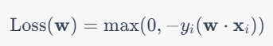

Where

- **w**: the weight vector
- **x*i***: The feature vector of the *i* example
- **y*i***: The actual label of the *i* example

**Optimization function**

The role of the optimization function is to minimize the previously described loss function. To do so, it adjusts the parameters of the model, which in this case would be the weights and the bias. It iterates each time over these parameters until there is no error or the epochs are finished.